# Podcasts Reviews Analysis

[figure not shown]

## DISCLAIMER: When viewing this notebook on Github

You have two options for optimal viewing experience:

1. ✅ open the notebook in jupyterlab instead of github (and re-run all cells)
   - Best if you want to verify that the code works and that the data is not fake
2. ✅ open the prerendered HTML file, which contains all of the data without any of the rendering limitations that github suffers from
   - Best if you just want to review the analysis and conclusions

❌ Do not open this notebook (.ipynb) in github as some charts/images might not be rendered correctly

Expand the next cell to see the entire explanation

### Explanation

Some charts/diagrams/features are not visible in github.

This impacts all:

- plotly plots
- folium maps
- embedded images
- and all other dynamic content

This is [standard and well-known behaviour](https://blog.jupyter.org/rendering-notebooks-on-github-f7ac8736d686).

While some workarounds could be possible, there are no fixes for **all** the issues.

- Plotly customization [requires installing external tools](https://github.com/plotly/plotly.py/issues/931), but doesn't fix the other issues
- Standard workarounds ([nbviewer](http://nbviewer.jupyter.org/)) do not work because the github repo is private.

# Context

The year is 2024, and **Apple has done it again!** 💲💸📈

[figure not shown]

After successfully monetizing 112/911 calls to emergency services, Apple's CEO is looking for ways to boost shareholders' portfolios even further.

A recent analysis of the company noticed that Apple Podcasts is not earning enough money and suggests that there might be potential for further profits in those products.

Apple is considering various avenues (a blue "verified" badge *a-la twitter*, etc..) but the most promising one is charging users to post reviews.

In typical Apple fashion, this is a secret project that will attempt to disrupt industry trends, but it needs a careful rollout to avoid "big bang" changes that would require embarrassing rollbacks or public apologies.

Our mission is to understand the Apple Podcast universe, extract insights and find interesting patterns.

Ideally they would like to know:

- Where are our cash cows: who are our engaged users who write the most?
- Which categories should we monetize first?

## Our approach

- Bot detection: Are there any obvious signs of bot-like behaviour that could impact our analysis?
- User engagement: Which users are the most active in the platform? Which ones are not as active?
- User engagement: How do those two groups of users behave on their own?
- Market Segmentation: How do these groups compare with each other? Are they actually behaving differently?
- Finding trendy categories: If these 2 groups behave differently, how are they engaging with the content (comparatively)?
- Provide summary of findings with:
  - First users to monetize
  - First categories to be "VIP premium gold-tier podcast categories"
  - Final thoughts on how to alienate our users even further?
  - Roll out plan
  - Public letter blaming external market forces that made us do it, against our will.

With this plan on the table, we are ready to start!

# Let's get started!

💭 If you are running this locally, remember to `pip install -r requirements.txt` before proceeding

```python
%reload_ext autoreload
%autoreload 1

from IPython.display import display, Markdown
import matplotlib.pyplot as plt
import matplotlib.patches as patches

import numpy as np
import pandas as pd
import seaborn as sns
import bisect
import duckdb
from scipy import stats

from random import random, seed
import sqlite3 as lite

from utils import handy_utils as util
from utils import pandas_auto_types as auto_pandas
from utils import auto_kaggle
from utils import chart_utils as charts
from utils import sql_utils as sql

from utils.handy_utils import run

%aimport utils.handy_utils
%aimport utils.auto_kaggle
%aimport utils.pandas_auto_types
%aimport utils.chart_utils
%aimport utils.sql_utils
```

Let's use `black` to auto-format all our cells so they adhere to PEP8

```python
import lab_black

%reload_ext lab_black
util.patch_nb_black()
```

```python
# when we use `black`, it removes the trailing semicolons that we use to silence plt messages.
# We are creating an alias for None so we can still have clean charts, in a way that black cannot remove
__ = None
```

```python
seed(100)
pd.options.display.max_rows = 100
pd.options.display.max_colwidth = 40

util.check("done")
```

```
yes! ✅
```

```python
def md(s: str) -> None:
    display(Markdown(s))
```

## Loading data

We're ready to start! Let's download the dataset from Kaggle.

We need to increase the timeout a bit, so it can complete the download of the 800+ MB dataset.

```python
dataset_name = "thoughtvector/podcastreviews"
db_filename = "database.sqlite"

auto_kaggle.download_dataset(dataset_name, db_filename, timeout_seconds=30)

sqlite = lite.connect("dataset/" + db_filename)
```

```
Kaggle API 1.5.12 - login as 'edualmas'
File [dataset/database.sqlite] already exists locally!
No need to re-download dataset [thoughtvector/podcastreviews]
```

Let's create some much needed indexes that will help us speed up our future queries (don't look, this code contains spoilers 😉 )

We can trade +300MB of extra storage, to speed up our queries by a factor of ~50x (based on empirical evidence). Sounds like a good deal!

```python
sql.create_index(sqlite, "main", "podcasts", ["podcast_id"])
sql.create_index(sqlite, "main", "reviews", ["podcast_id"])
sql.create_index(sqlite, "main", "categories", ["podcast_id"])

sql.create_index(sqlite, "main", "reviews", ["rating"])
sql.create_index(sqlite, "main", "reviews", ["author_id", "created_at", "rating"])
sql.create_index(sqlite, "main", "categories", ["category"])
```

```
creating index on main.podcasts ['podcast_id']... done ✅
creating index on main.reviews ['podcast_id']... done ✅
creating index on main.categories ['podcast_id']... done ✅
creating index on main.reviews ['rating']... done ✅
creating index on main.reviews ['author_id', 'created_at', 'rating']... done ✅
creating index on main.categories ['category']... done ✅
```

## Table overview

```python
all_tables = sql.list_tables(sqlite)
```

| table | rows |
| --- | --- |
| runs | 16 |
| podcasts | 110,024 |
| categories | 212,372 |
| reviews | 2,067,529 |
| category_rating | 4,529,483 |

The `runs` table

|  | run_at | max_rowid | reviews_added |
| --- | --- | --- | --- |
| 0 | 2021-05-10 02:53:00 | 3266481 | 1215223 |
| 1 | 2021-06-06 21:34:36 | 3300773 | 13139 |
| 2 | 2021-07-02 18:04:55 | 3329699 | 11561 |
| 3 | 2021-08-01 17:54:42 | 3360315 | 11855 |
| 4 | 2021-09-02 18:00:30 | 3390165 | 11714 |
| 5 | 2021-10-11 05:18:23 | 3428923 | 16845 |
| 6 | 2022-04-20 01:03:30 | 3855531 | 36589 |
| 7 | 2022-06-05 16:15:16 | 3855531 | 0 |
| 8 | 2022-06-22 19:44:32 | 4479220 | 29146 |
| 9 | 2022-07-03 19:50:22 | 5149673 | 559523 |

The `podcasts` table

|  | podcast_id | itunes_id | slug | itunes_url | title |
| --- | --- | --- | --- | --- | --- |
| 0 | a00018b54eb342567c94dacfb2a3e504 | 1313466221 | scaling-global | https://podcasts.apple.com/us/podcas... | Scaling Global |
| 1 | a00043d34e734b09246d17dc5d56f63c | 158973461 | cornerstone-baptist-church-of-orlando | https://podcasts.apple.com/us/podcas... | Cornerstone Baptist Church of Orlando |
| 2 | a0004b1ef445af9dc84dad1e7821b1e3 | 139076942 | mystery-dancing-in-the-dark | https://podcasts.apple.com/us/podcas... | Mystery: Dancing in the Dark |
| 3 | a00071f9aaae9ac725c3a586701abf4d | 1332508972 | kts-money-matters | https://podcasts.apple.com/us/podcas... | KTs Money Matters |
| 4 | a000a500f06555f81220c3eb641aded7 | 1544900779 | word-on-the-street-w-dreak-swift | https://podcasts.apple.com/us/podcas... | Word on the Street w/ Dreak Swift |
| 5 | a000aa69852b276565c4f5eb9cdd999b | 1342447811 | speedway-soccer | https://podcasts.apple.com/us/podcas... | Speedway Soccer |
| 6 | a000b6538cca860a11a94607c13e9595 | 1568973037 | showing-up-for-you | https://podcasts.apple.com/us/podcas... | Showing Up for You |
| 7 | a0010b283ba17d282c7bb1f9709f0ac3 | 1285218356 | bethany-baptist-church-bellflower-ca | https://podcasts.apple.com/us/podcas... | Bethany Baptist Church, Bellflower CA |
| 8 | a0013c50c1e6b24266fdeb10eed6eea7 | 1448380200 | mindful-communication-podcast | https://podcasts.apple.com/us/podcas... | Mindful Communication Podcast |
| 9 | a00155a1dc1d1b9ef4d2d573982207c6 | 1500634531 | marvels | https://podcasts.apple.com/us/podcas... | MARVELS |

The `categories` table

|  | podcast_id | category |
| --- | --- | --- |
| 0 | c61aa81c9b929a66f0c1db6cbe5d8548 | arts |
| 1 | c61aa81c9b929a66f0c1db6cbe5d8548 | arts-performing-arts |
| 2 | c61aa81c9b929a66f0c1db6cbe5d8548 | music |
| 3 | ad4f2bf69c72b8db75978423c25f379e | arts |
| 4 | ad4f2bf69c72b8db75978423c25f379e | arts-design |
| 5 | ad4f2bf69c72b8db75978423c25f379e | education |
| 6 | ad4f2bf69c72b8db75978423c25f379e | society-culture |
| 7 | f2970432aad718a000ebac10e48ae6b0 | arts |
| 8 | f2970432aad718a000ebac10e48ae6b0 | arts-performing-arts |
| 9 | f2970432aad718a000ebac10e48ae6b0 | society-culture |

The `reviews` table

|  | podcast_id | title | content | rating | author_id | created_at |
| --- | --- | --- | --- | --- | --- | --- |
| 0 | c61aa81c9b929a66f0c1db6cbe5d8548 | really interesting! | Thanks for providing these insights.... | 5 | F7E5A318989779D | 2018-04-24T12:05:16-07:00 |
| 1 | c61aa81c9b929a66f0c1db6cbe5d8548 | Must listen for anyone interested in... | Super excited to see this podcast gr... | 5 | F6BF5472689BD12 | 2018-05-09T18:14:32-07:00 |
| 2 | ad4f2bf69c72b8db75978423c25f379e | nauseatingly left | I'm a liberal myself, but its pretty... | 1 | 1AB95B8E6E1309E | 2019-06-11T14:53:39-07:00 |
| 3 | ad4f2bf69c72b8db75978423c25f379e | Diverse stories | I find Tedx talks very inspirational... | 5 | 11BB760AA5DEBD1 | 2018-05-31T13:08:09-07:00 |
| 4 | ad4f2bf69c72b8db75978423c25f379e | 👍👍👍👍 | I love this podcast, it is so good. | 5 | D86032C8E57D15A | 2019-06-19T13:56:05-07:00 |
| 5 | ad4f2bf69c72b8db75978423c25f379e | Waste of time | I listened to the “Spanish Flu” pod ... | 1 | 67A452C80BCBEEC | 2019-01-09T09:07:09-07:00 |
| 6 | ad4f2bf69c72b8db75978423c25f379e | Too much victimology | Too much BS trying to convince me of... | 3 | 265ADD6AB150C41 | 2019-02-02T10:15:25-07:00 |
| 7 | ad4f2bf69c72b8db75978423c25f379e | Politically biased | I would love to hear topics discusse... | 1 | C27BC8C2D6F5A4A | 2019-01-01T09:47:11-07:00 |
| 8 | ad4f2bf69c72b8db75978423c25f379e | 😀😃 | Ok so I am in love with this podcast. | 5 | 218EE494C8C787F | 2019-05-09T17:50:14-07:00 |
| 9 | ad4f2bf69c72b8db75978423c25f379e | Volume??? | Great podcast, but the editors turn ... | 1 | DC6DBB8C4D9B2E5 | 2019-06-25T05:05:24-07:00 |

The `category_rating` table

|  | podcast_id | category | author_id | rating |
| --- | --- | --- | --- | --- |
| 0 | c61aa81c9b929a66f0c1db6cbe5d8548 | arts | F7E5A318989779D | 5 |
| 1 | c61aa81c9b929a66f0c1db6cbe5d8548 | arts-performing-arts | F7E5A318989779D | 5 |
| 2 | c61aa81c9b929a66f0c1db6cbe5d8548 | music | F7E5A318989779D | 5 |
| 3 | c61aa81c9b929a66f0c1db6cbe5d8548 | arts | F6BF5472689BD12 | 5 |
| 4 | c61aa81c9b929a66f0c1db6cbe5d8548 | arts-performing-arts | F6BF5472689BD12 | 5 |
| 5 | c61aa81c9b929a66f0c1db6cbe5d8548 | music | F6BF5472689BD12 | 5 |
| 6 | ad4f2bf69c72b8db75978423c25f379e | arts | 1AB95B8E6E1309E | 1 |
| 7 | ad4f2bf69c72b8db75978423c25f379e | arts-design | 1AB95B8E6E1309E | 1 |
| 8 | ad4f2bf69c72b8db75978423c25f379e | education | 1AB95B8E6E1309E | 1 |
| 9 | ad4f2bf69c72b8db75978423c25f379e | society-culture | 1AB95B8E6E1309E | 1 |

### Table Summary

- the `runs` table seems to be metadata about how frequently this dataset is updated. Can be ignored.
  - if this dataset had historical snapshots in kaggle, and we were interested in seeing the changes over time (eg. which new podcasts appeared between each of the snapshots), we might be able to use those intermediate datasets to get a better understanding of the evolution over time. But this if out of scope for now.
- the `podcasts` has 4 different types of "*unique IDs*", and their human readable title. this table might be useful to aggregate reviews, but not much can be extracted from here, other than (maybe) keywords/tokens from the slug.
- the `categories` table has *tags* that are attached to a given podcast. seems to be a M:N relation.
- the `reviews` table has over 2M rows (also a M:N), includes very interesting data:
  - data about the podcasts, including rating and tokenizable strings
  - data about authors: the author id, and the timestamps of each comment, potentially allowing us to detect abusers (bots, etc... ?)

## Let's create some needed tables to improve performance of future queries

```python
if "category_rating" not in all_tables:
    print("Creating table [category_rating]....", end="")
    s = """
    BEGIN TRANSACTION;
        CREATE TABLE category_rating(podcast_id TEXT, category TEXT, author_id TEXT, rating INT);
        INSERT INTO category_rating
            SELECT p.podcast_id, c.category, r.author_id, r.rating
            FROM podcasts p
                INNER JOIN reviews r ON r.podcast_id = p.podcast_id
                INNER JOIN categories c ON p.podcast_id = c.podcast_id
                ;
    COMMIT;
    """
    sqlite.executescript(s)
    print("Done ✅")

sql.create_index(sqlite, "main", "category_rating", ["category", "rating"])
```

```
creating index on main.category_rating ['category', 'rating']... done ✅
```

## Initial overview

Before we get into statistical analysis and in-depth exploration, we need to get a general understanding of the types of data that is hiding in our dataset.

This includes:

- How are podcasts generally rated (any bias?)
- How are tags/categories generally applied into podcasts? (any patterns?)
- How are the users behaving?
  - Are there any demographics/tribes we can cluster them in? (haters, mega fans, upvote bots, downvote bots, ...)
- Are any of these discoveries worrying enough that we would like to exclude them from our future analysis?

### Podcast

Let's get started with the podcast.

It would be great if the dataset included some extra data (number of episodes, episode cadence, first publish date, etc...) to get a better understanding of the types of podcasts we're looking at, but we might be able to derive some of these from other places (eg. reviews timestamps...)

For now, we just want to see:

- how are the ratings spread between ⭐ - - - - and ⭐⭐⭐⭐⭐
  - is there any kind of skewness?
- how are the categories assigned:
  - are there patterns that apply to all of them (are they centrally managed?)
  - is there a wide variety in terms of spread (can each author mark their own podcast?)
  - are there hot categories that authors might use to try to increase their visibility?

```python
q_rating_groups = """
SELECT COUNT(*) as reviews, rating
FROM reviews
GROUP BY rating
ORDER BY rating
"""

df_rating_groups = pd.read_sql_query(q_rating_groups, sqlite)
df_rating_groups["rating_formatted"] = df_rating_groups["rating"].apply(
    lambda num: "⭐" * num
)
df_rating_groups["reviews_formatted"] = df_rating_groups["reviews"].apply(
    lambda num: "{:,}".format(num)
)
df_rating_groups[["rating_formatted", "reviews_formatted"]]
```

|  | rating_formatted | reviews_formatted |
| --- | --- | --- |
| 0 | ⭐ | 116,547 |
| 1 | ⭐⭐ | 45,866 |
| 2 | ⭐⭐⭐ | 52,176 |
| 3 | ⭐⭐⭐⭐ | 62,883 |
| 4 | ⭐⭐⭐⭐⭐ | 1,790,057 |

This distribution of ratings seems quite on-par with what we see in most online stores/VIP showrooms/shops.

A strongly polarized skew towards 5⭐ (the supporters), a second -*smaller*- peak around the 1⭐ mark (the haters), and an even spread across the 2-3-4 ⭐ ratings.

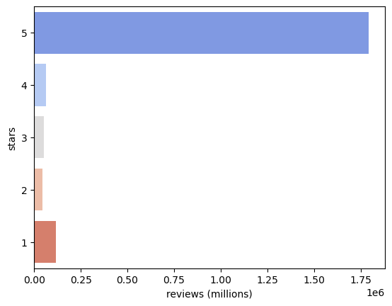

```python
sns.barplot(
    data=df_rating_groups,
    y="rating",
    x="reviews",
    orient="h",
    order=reversed(df_rating_groups["rating"]),
    palette="coolwarm",
)
plt.title("")
plt.xlabel("reviews (millions)")
plt.ylabel("stars")
```

```python
q_category_spread = """
WITH categories_per_podcast AS (
        SELECT p.podcast_id,
               COUNT(c.category) category_count
        FROM podcasts p
                 LEFT OUTER JOIN categories c on p.podcast_id = c.podcast_id
        GROUP BY p.podcast_id
    ),
    zero_to_ten(num) AS (
        VALUES (0), (1), (2), (3), (4), (5), (6), (7), (8), (9), (10)
    )
SELECT z.num as category_count,
       COUNT(c.podcast_id) number_of_podcasts
FROM zero_to_ten z
         LEFT OUTER JOIN categories_per_podcast c ON z.num = c.category_count
GROUP BY z.num
"""

df_category_spread = sql.peek("### Category Spread", q_category_spread, sqlite)
```

Category Spread

|  | category_count | number_of_podcasts |
| --- | --- | --- |
| 0 | 0 | 0 |
| 1 | 1 | 44455 |
| 2 | 2 | 39443 |
| 3 | 3 | 16491 |
| 4 | 4 | 8809 |
| 5 | 5 | 658 |
| 6 | 6 | 147 |
| 7 | 7 | 18 |
| 8 | 8 | 3 |
| 9 | 9 | 0 |
| 10 | 10 | 0 |

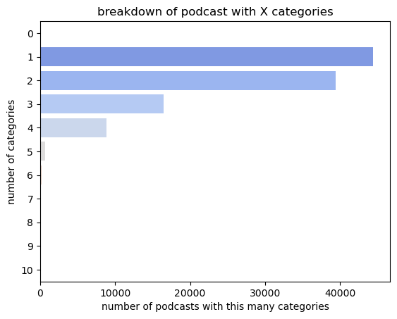

```python
ax = sns.barplot(
    data=df_category_spread,
    y="category_count",
    x="number_of_podcasts",
    orient="h",
    palette="coolwarm",
)

plt.title("breakdown of podcast with X categories")
plt.xlabel("number of podcasts with this many categories")
plt.ylabel("number of categories")
```

It seems that the vast majority of podcasts have 1 or 2 tags.

A very small of podcasts amount have 5 or more tags.

No podcasts have 0 categories (it's likely that this is a required field), or more than 8 (this makes us thing that there might also be a max. number of categories that they can enter... )

### Review Spread

```python
q_reviews_per_podcast = """
WITH review_per_podcast AS (SELECT r.podcast_id, COUNT(*) review_count
                            FROM reviews r
                            GROUP BY r.podcast_id),
     hits_per_review AS (SELECT review_count, COUNT(*) AS podcast_count
                         FROM review_per_podcast
                         GROUP BY review_count)
SELECT review_count, podcast_count,
       CASE
           WHEN (review_count BETWEEN 1 AND 10) THEN review_count
           WHEN (review_count BETWEEN 11 AND 20) THEN '11 to 20'
           ELSE '21+' END AS category
FROM hits_per_review
"""
df_reviews_per_podcast = pd.read_sql_query(q_reviews_per_podcast, sqlite)
df_reviews_per_podcast.head()
```

|  | review_count | podcast_count | category |
| --- | --- | --- | --- |
| 0 | 1 | 36638 | 1 |
| 1 | 2 | 17310 | 2 |
| 2 | 3 | 10128 | 3 |
| 3 | 4 | 7032 | 4 |
| 4 | 5 | 5105 | 5 |

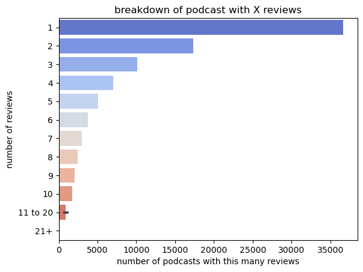

```python
sns.barplot(
    data=df_reviews_per_podcast,
    y="category",
    x="podcast_count",
    orient="h",
    palette="coolwarm",
)

plt.xlabel("number of podcasts with this many reviews")
plt.ylabel("number of reviews")
plt.title("breakdown of podcast with X reviews")
__
```

Let's see the other end of the spectrum:

```python
df_reviews_per_podcast.tail()
```

|  | review_count | podcast_count | category |
| --- | --- | --- | --- |
| 899 | 7389 | 1 | 21+ |
| 900 | 8248 | 1 | 21+ |
| 901 | 9698 | 1 | 21+ |
| 902 | 10675 | 1 | 21+ |
| 903 | 33104 | 1 | 21+ |

Fantastic! We have 1 (one) podcast with more than 33k reviews. this is more than 3x its closest competitor!

It's either a super-scam upvoted by bots, or the podcast with The Kardashians going to a bake-off challenge, where they compete to resolve a true crime in realtime with a famous hipster polyamorous vegan who lifts, *bruh*...

But, in general, the spread is not outlandish, and seems reasonable.

Before we move on, let's change a couple of things:

1. We will switch to using **DuckDB** some of the queries:
   - **AS AN** Aspiring Data Scientist
   - **I WANT TO** use real SQL for my queries
   - **SO THAT** I don't have to write crazy, slow, unreadable pandas-style joins, nor commit other crimes against humanity
     - **AND** (to be honest.. I really want to try it out...)
2. We will actively try to manage our memory better
   - **AS AN** Aspiring Data Scientist working on a "*large*" (800MB) dataset
   - **I WANT TO** start being proactive in my memory management skills
   - **SO THAT** I don't pollute the global scope with un-collectable garbage.
     - **AND** I really hope this skill will be more and more useful as larger and larger datasets get introduced in future sprints

So... without further delay...

### Number 1 - Let's give DuckDB a chance ...

- for [more efficient queries](https://duckdb.org/2021/05/14/sql-on-pandas.html)
- [better performance](https://duckdb.org/why_duckdb)
- easier to read logic
- pure sql 💛
- and also... to try it out

and let's find out if this tool is as cool as they claim it to be, or if it has any unexpected limiations or usability issues.

For some complex queries we will still use the previous sqlite engine (non-duckdb engine) as some of the queries are a bit easier to write in sqlite flavor (just for our comfort, and to avoid having to learn yet another flavour of sql: eg. when trying to calculate number of days between 2 dates, etc..)

```python
sqlite.close()
```

```python
duck = duckdb.connect("dataset/database.sqlite", read_only=True)
sqlite = lite.connect("dataset/" + db_filename)
```

with this piece of code, we can open a new connection to the same database, through *DuckDB*.

Since DuckDB does not like sharing a connection to an already open DB, let's close the previous connection and let DuckDB have first-pick, but in readonly mode so it allows other users... and then let's reopen it via the sqlite engine normally (after duckdb is happy).

This step also help us make sure that all the previous operations (indexing commands, etc.. are fully committed before letting duckdb open the DB, so it can benefit from the performance boost)

### ... and Number 2 - Let's manage our memory more intentionally

by reducing the scope of our operations, to let the garbage collector remove all unnecessary/intermediate variables

We created a custom decorator that immediately executes the decorated function (similar to the *self-executing function* pattern in javascript)

This also has the other advantage that:

- if we ever need to modify global variables, we will have to explicitly request it, avoiding accidental/implicit access

```python
@run
def _():
    return duck.query("SELECT * FROM categories").to_df().head()
```

|  | podcast_id | category |
| --- | --- | --- |
| 0 | c61aa81c9b929a66f0c1db6cbe5d8548 | arts |
| 1 | c61aa81c9b929a66f0c1db6cbe5d8548 | arts-performing-arts |
| 2 | c61aa81c9b929a66f0c1db6cbe5d8548 | music |
| 3 | ad4f2bf69c72b8db75978423c25f379e | arts |
| 4 | ad4f2bf69c72b8db75978423c25f379e | arts-design |

Nice! Everything seems to work 😍

### Let's investigate categories

|  | category | counts |
| --- | --- | --- |
| 0 | society-culture | 18710 |
| 1 | education | 12628 |
| 2 | comedy | 12464 |
| 3 | religion-spirituality | 12190 |
| 4 | business | 12058 |
| ... | ... | ... |
| 105 | science-physics | 18 |
| 106 | sports-swimming | 18 |
| 107 | science-chemistry | 17 |
| 108 | science-mathematics | 16 |
| 109 | sports-volleyball | 14 |

110 rows × 2 columns

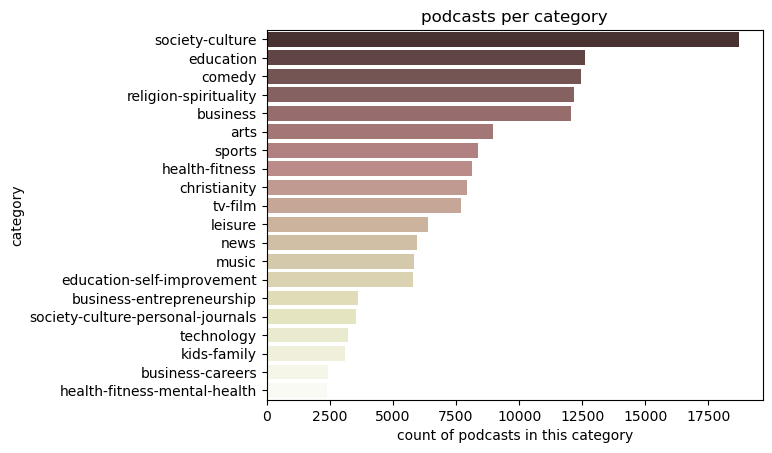

```python
@run
def _():
    q = """
    SELECT category, COUNT(podcast_id) counts
    FROM categories
    GROUP BY category
    ORDER BY counts DESC
    """
    x = duck.query(q).to_df()
    sns.barplot(orient="h", data=x.head(20), y="category", x="counts", palette="pink")
    plt.title("podcasts per category")
    plt.xlabel("count of podcasts in this category")
    return x
```

|  | category | counts |
| --- | --- | --- |
| 0 | society-culture | 18710 |
| 1 | education | 12628 |
| 2 | comedy | 12464 |
| 3 | religion-spirituality | 12190 |
| 4 | business | 12058 |
| ... | ... | ... |
| 105 | science-physics | 18 |
| 106 | sports-swimming | 18 |
| 107 | science-chemistry | 17 |
| 108 | science-mathematics | 16 |
| 109 | sports-volleyball | 14 |

110 rows × 2 columns

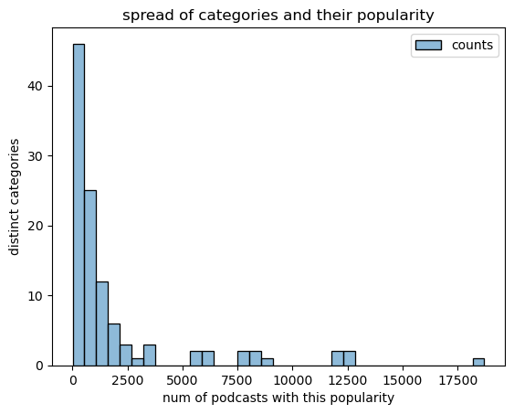

```python
@run
def _():
    q = """
    SELECT category, COUNT(podcast_id) counts
    FROM categories
    GROUP BY category
    ORDER BY counts DESC
    """
    x = duck.query(q).to_df()
    display(x)
    sns.histplot(data=x)
    plt.xlabel("num of podcasts with this popularity")
    plt.ylabel("distinct categories")
    plt.title("spread of categories and their popularity")
```

It seems that there's a pretty wide spread of categories, with some clear clustering towards the top end of the popularity spectrum (society-culture, education, comedy... ) while the least popular categories barely get 10-20 podcasts about those *niche* topics (volleyball, mathematics, swimming...)

```python
@run
def _():
    q = """
    SELECT COUNT(DISTINCT category) as unique_categories
    FROM categories
    """
    x = duck.query(q).to_df()
    return x
```

|  | unique_categories |
| --- | --- |
| 0 | 110 |

```python
@run
def _():
    q = """
    SELECT *
    FROM podcasts
    WHERE podcast_id NOT IN (SELECT podcast_id FROM categories)
    """
    x = duck.query(q).to_df()
    return x
```

|  | podcast_id | itunes_id | slug | itunes_url | title |
| --- | --- | --- | --- | --- | --- |

We also notice that all of the podcasts have categories assigned. We suspect it might be a required field. this will make our job easier

### Let's investigate reviewers

We'd like to see if there are accounts that look like bots (too many reviews, or reviews that are entered too frequently)

```python
def _():
    q = """
    WITH authors AS (
        SELECT author_id,
               COUNT(*) counts,
               MIN(created_at) start,
               MAX(created_at) end,
               (JULIANDAY(MAX(created_at)) -
                JULIANDAY(MIN(created_at))) days_diff,
               MAX(rating) - MIN(rating) rating_spread,
               AVG(rating) avg_rating
        FROM reviews
        GROUP BY author_id
        HAVING counts > 1
    )
    SELECT author_id,
           counts as comments,
           days_diff as days,
           counts / days_diff as comments_per_day,
           rating_spread,
           avg_rating,
           CASE
               WHEN counts > 2 AND avg_rating > 4.5 THEN 'UPVOTE'
               WHEN counts > 2 AND avg_rating <= 2 THEN 'DOWNVOTE'
               ELSE 'FAIR' END AS behaviour,
           CASE
               WHEN counts > 2 AND rating_spread <= 1 THEN 'NARROW'
               WHEN counts > 2 AND avg_rating > 4 THEN 'WIDE'
               ELSE 'HALF' END AS spread
    FROM authors
    ORDER BY comments_per_day DESC;
    """
    x = pd.read_sql_query(q, sqlite)
    return x


comment_rates = _()
comment_rates
```

|  | author_id | comments | days | comments_per_day | rating_spread | avg_rating | behaviour | spread |
| --- | --- | --- | --- | --- | --- | --- | --- | --- |
| 0 | ACFD7CA4DF3D9EA | 6 | 0.000012 | 518402.811829 | 0 | 5.0 | UPVOTE | NARROW |
| 1 | 604C634B4700920 | 4 | 0.000012 | 345587.970389 | 0 | 5.0 | UPVOTE | NARROW |
| 2 | 43D7A1583D19387 | 3 | 0.000012 | 259201.405914 | 0 | 5.0 | UPVOTE | NARROW |
| 3 | 62328A42DF7C61D | 3 | 0.000012 | 259201.405914 | 0 | 5.0 | UPVOTE | NARROW |
| 4 | D6B5DDA45FADA44 | 3 | 0.000012 | 259201.405914 | 0 | 5.0 | UPVOTE | NARROW |
| ... | ... | ... | ... | ... | ... | ... | ... | ... |
| 275890 | F814F2E8B90FC24 | 2 | 0.000000 | NaN | 0 | 5.0 | FAIR | HALF |
| 275891 | F93BCD57980E50C | 2 | 0.000000 | NaN | 0 | 5.0 | FAIR | HALF |
| 275892 | FCB474E1F6C7C00 | 3 | 0.000000 | NaN | 0 | 4.0 | FAIR | NARROW |
| 275893 | FD7A4E53F90ED9C | 2 | 0.000000 | NaN | 0 | 5.0 | FAIR | HALF |
| 275894 | FF4C3CEC478CAA6 | 2 | 0.000000 | NaN | 0 | 5.0 | FAIR | HALF |

275895 rows × 8 columns

Alright... It seems we have lots of problems, at both ends of the extreme values:

- from users that can enter 6 reviews in .000012 days (6 reviews in 1.03 seconds), giving us a rate of half-a-millions reviews per day! (take that, BuzzFeed Quiz Writers!)
- to users that can enter 2 comments at the same millisecond

Let's take a look at the comments behind the first and last rows, to get a better understanding.

```python
@run
def _():
    q = """
    SELECT *
    FROM reviews
    WHERE author_id IN ('ACFD7CA4DF3D9EA', 'FF4C3CEC478CAA6');
    """
    x = pd.read_sql_query(q, sqlite)
    return x
```

|  | podcast_id | title | content | rating | author_id | created_at |
| --- | --- | --- | --- | --- | --- | --- |
| 0 | db7cab83fbf7920f8ee8385f05449522 | Lord of the Ultra-Realm | These boys jaw a lot, throw in a cou... | 5 | ACFD7CA4DF3D9EA | 2018-09-08T00:30:13-07:00 |
| 1 | db7cab83fbf7920f8ee8385f05449522 | Lord of the Ultra-Realm | These boys jaw a lot, throw in a cou... | 5 | ACFD7CA4DF3D9EA | 2018-09-08T00:30:13-07:00 |
| 2 | db7cab83fbf7920f8ee8385f05449522 | Lord of the Ultra-Realm | These boys jaw a lot, throw in a cou... | 5 | ACFD7CA4DF3D9EA | 2018-09-08T00:30:13-07:00 |
| 3 | db7cab83fbf7920f8ee8385f05449522 | Lord of the Ultra-Realm | These boys jaw a lot, throw in a cou... | 5 | ACFD7CA4DF3D9EA | 2018-09-08T00:30:13-07:00 |
| 4 | db7cab83fbf7920f8ee8385f05449522 | Lord of the Ultra-Realm | These boys jaw a lot, throw in a cou... | 5 | ACFD7CA4DF3D9EA | 2018-09-08T00:30:14-07:00 |
| 5 | db7cab83fbf7920f8ee8385f05449522 | Lord of the Ultra-Realm | These boys jaw a lot, throw in a cou... | 5 | ACFD7CA4DF3D9EA | 2018-09-08T00:30:14-07:00 |
| 6 | b80e53c84f71dbd882b917e44d0b8e2e | Fantastic Pod Cast | Y’all’s show is the best I have foun... | 5 | FF4C3CEC478CAA6 | 2019-11-01T15:08:54-07:00 |
| 7 | b80e53c84f71dbd882b917e44d0b8e2e | Fantastic Pod Cast | Y’all’s show is the best I have foun... | 5 | FF4C3CEC478CAA6 | 2019-11-01T15:08:54-07:00 |

Looking at the timestamps, we see there is some serious duplication, and we can classify it into 2 types:

- what we will call **DOUBLE SUBMIT** type: where the **entire row** is identical (as we see for the second commenter `FF4C3CEC478CAA6`)
- what we will call **SPAMMING** type: where the podcast/title/content/rating are the same, but they have **different timestamps** (as we see in some of the comments by the first commenter `ACFD7CA4DF3D9EA`)

The first example actually suffers from both types.

Given that we see users that suffer both, we might have to start considering that maybe it's not an issue with the dataset... but an attack/bot attempting to influence podcasts ratings.

This will require a more in-depth analysis to try to spot bot-like behaviour.

## Understanding reviewers' behaviours and the value they provide

We want to understand how many of the reviewers fall into bot-like behaviour, to understand if this dataset is legit, or if it's filled with paid opinions.

### Spamming Analysis

Let's go back to our comment_rate analysis we did ealier, and try to visualize it completely

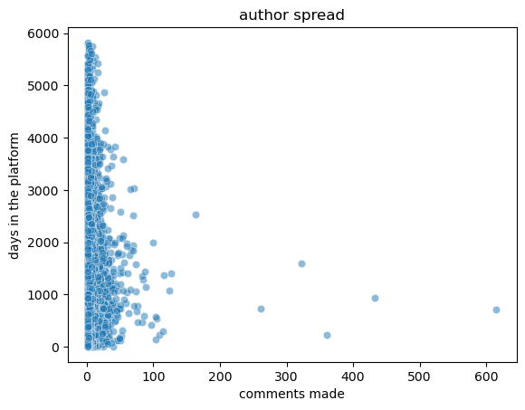

```python
def comment_spread_plot(sample_size: int, alpha=0.5, **kwargs):
    # let the caller specify the sample size so rendering doesn't use all 200k points
    plt.title("spread of comments/reviews")
    return sns.scatterplot(
        data=comment_rates.sample(sample_size),
        x="comments",
        y="days",
        alpha=alpha,
        **kwargs,
    )


comment_spread_plot(sample_size=70_000)
plt.title("author spread")
plt.xlabel("comments made")
plt.ylabel("days in the platform")
__
```

#### Let's mark some areas of interest

```python
def highlight_area(x, y, width, height, label, color):
    plt.gca().add_patch(
        patches.Rectangle(
            (x, y),
            width,
            height,
            edgecolor="darkblue",
            facecolor="yellow",
            fill=True,
            lw=0.5,
            alpha=0.3,
        )
    )
    plt.gca().annotate(
        label,
        (x, y),
        color="black",
        weight="ultralight",
        fontsize=9,
        ha="center",
        va="top",
    )
```

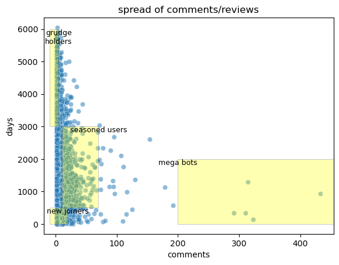

```python
comment_spread_plot(sample_size=70_000)

highlight_area(5, 6000, -15, -3000, "grudge\nholders", 0)
highlight_area(70, 3000, -60, -2500, "seasoned users", 0)
highlight_area(20, 500, -30, -500, "new joiners", 0)
highlight_area(200, 2000, 600, -2000, "mega bots", 0)
```

It's pretty clear that there are interesting spots:

Let's dig deeper into the lower/left hand corner

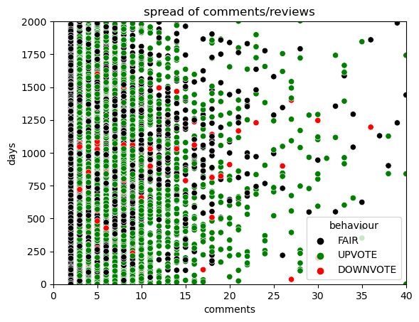

```python
review_palette = {"UPVOTE": "green", "FAIR": "black", "DOWNVOTE": "red"}

plt.xlim(0, 40)
plt.ylim(0, 2000)
comment_spread_plot(sample_size=50_000, alpha=1, palette=review_palette, hue="behaviour")
__
```

Let's remember the criteria for "behaviour"

```
CASE
   WHEN counts > 2 AND avg_rating > 4.5 THEN 'UPVOTE'
   WHEN counts > 2 AND avg_rating <= 2 THEN 'DOWNVOTE'
   ELSE 'FAIR' END AS behaviour,
```

- Considering the stringent requirements, we can see that a lot of reviews come from polarized reviewers.

We could spend hours drafting and choosing thresholds to try to find the most bot-like behaviour, but it's impossible to do this without biasing our study with our preconceptions.

And, when looking at the data, beyond the most obvious bots, the rest seem quite reasonable and legitimate.

#### The impossibility of choosing a threshold

It's practically impossible to chose a threshold without attaching our bias to it.... When should we consider that "someone is very active" in the platform?

We need to find tools that will help us make a more informed decision than just saying *"50 total comments is the cuttoff point"*...

**Our next section will focus on precisely that, using statistical tools and knowledge to help us determine a better way to decide these threshold.**

```python
q_reviewer_activity_spread = """
WITH author_activity AS (
    SELECT author_id,
            COUNT(*)                   counts,
            JULIANDAY(MIN(created_at)) start,
            JULIANDAY(MAX(created_at)) end
     FROM reviews
     GROUP BY author_id)
SELECT author_id,
       end - start                        as active_time,
       counts,
       CASE
           WHEN ((end - start) <= 1) THEN 'less than 24h'
           ELSE 'more than 24h' END       AS active_time_category,
       CASE
           WHEN counts <= 1 THEN 'single comment'
           ELSE 'more than 1 comment' END AS comment_volume_category
FROM author_activity
"""


def _():
    df_rev_activity = pd.read_sql_query(q_reviewer_activity_spread, sqlite)
    # let's try this fantastic feature! using duckdb to treat in-memory-dataframes as queriable tables! 🤩🤩
    return duckdb.query_df(
        df_rev_activity,
        "df_rev_activity",
        """
        SELECT active_time_category, comment_volume_category, COUNT(*) as total
        FROM df_rev_activity
        GROUP BY active_time_category, comment_volume_category;""",
    ).to_df()


review_activity_types = _()
review_activity_types
```

|  | active_time_category | comment_volume_category | total |
| --- | --- | --- | --- |
| 0 | less than 24h | single comment | 1199388 |
| 1 | more than 24h | more than 1 comment | 256683 |
| 2 | less than 24h | more than 1 comment | 19212 |
| 3 | more than 24h | single comment | 2 |

Let's pause for a second to reflect on this tool.

yup... as you can see, we cannot use [the simple `.query()` method](https://duckdb.org/2021/05/14/sql-on-pandas.html) directly because DuckDB cannot introspect/see the variables defined inside our own custom functions (even though they are in the same scope). Yes, it's still **super-magic**, but not **super-duper-magic**.

This quick showcase works, but took a bit to figure out why it didn't work the first few times.

We have to downgrade ourselves (and our self-esteem) to non-awesome developers levels, and we have to humilate ourselves and include 2 extra parametres, to help duckdb resolve the variable we are referencing 😒 big *ugh!*

Now, a bit more seriously... It might not be 100% awesome, but it's definitely 99.8% awesome, nonetheless (that's statistically-significant awesomeness)

Between, you and me, what it does is already "too far" for my comfort: in some cases, it attempts to find "variables named like x" instead of failing early... this is flaky and freaky... not a fan.

I think that if it did the "introspect inside functions" as well, I would be a lot more displeased. Making a tool too smart easily start getting into simple-reasoning and leads to more confusion, more unexpected behaviours and longer debugging.

I think they are hitting a fair trade-off.

Anyway, back to our analysis! We need to continue: let's convert the previous output to a pivot table

```python
review_activity_types.pivot(
    index="active_time_category", columns="comment_volume_category", values="total"
)
```

| comment_volume_category active_time_category | more than 1 comment | single comment |
| --- | --- | --- |
| less than 24h | 19212 | 1199388 |
| more than 24h | 256683 | 2 |

### Maybe bots are harder to find...

Alright... It seems our theory around "fake/bot reviews" doesn't hold up... if it did ... 80% of them would be incorrectly classified as bots..

This gives us an important lessons learned: trying to classify bots based on "single review" will not work.

Let's leave this as something we could do in the future, and assume that they are all legit (for now), so we can start getting into the important part of the analysis

The **Inferential Statistical Analysis**

# Feedback request for you (the reader/corrector)

Since this is my first time doing inferential statistical analysis, creating confidence intervals, using t-tests, etc... **I would like you to focus particularly in this section and try to find if I am using, the correct terminology, the correct functions/tools, the correct parameters**, etc..

My deal with you is this:

- I will try to walk you through all my thinking/reasoning, as clearly as I can
- In exchange, I would appreciate it if **you could be as picky, annoying, and petulent as possible** with any bugs, errors, omissions that you see, or with any misunderstandings I may have acquired.
  - I honestly believe this will help me a lot. The material in this sprint has been very theoretical and non-pragmatic, and **your correction represents one of the few chances I have to fully learn** what are the things that I think I know.. but I actually don't!
  - Thanks for your time in doing this :)

I will not complain if you come with a list of EVERYTHING that does not make sense.

In fact,

I can guarantee right now that there is at least 1 error in the following analysis.

If you can find it, I will __________ and also _________________ for the rest of the year 2023 *(#TO DO: Insert vague promise of future wealth, happiness, or .. something).*

..

After breaking the 4th wall in such an uncalled and unnecessary way... let's try to repair it and go back to our narrative with Mr. Tim Cook, to try to restore the illusion that we're working hard to make the world a better place!

Alright! Let's get started with our statistical analysis 🙂

Are you ready?

So am I :)

Alright! We made it! So far:

1. We got the dataset
2. We took a quick peek at the data to understand how it's shaped
3. We attempted to find if there were any clear problems with it ...

It's time to start raising hypothesis and using the data in the dataset to see if they make (some) sense.

We will use some of the newly learned tools, to try to get insights.

# Statistical Analysis

Let's compare differences between different types of users. For the rest our our study, we will assume that all our users are legitimate users, and it's just that some are way more chatty than others

We want to find out if there are any major differences across different user groups, based on their engagement.

Specifically, we want to see if *chatty users* engage with different categories of podcasts than *quiet users*.

### Our Hypotheses

- $h_0$: Chatty users engage with the same categories as quiet users
- $h_a$: Chatty users engage with a different set of categories than quiet users
  - future research avenues: are these few-but-chatty-users bots? are they being paid to boost specific podcasts/categories? ...

our fundamental assumptions is that different user groups vote/review podcasts differently, and that one optimal way to group them by is their chattiness/engagement with the platform.

## Test 1 - Identifying *chatty users -v- quiet users*

We believe some of the commenters are commenting at a rate that's well above average. We are calling them *chatty users*.

We intend to find those, so we can compare them to the rest of them (*quiet users*).

We would like to use a statistical tool to help us determine the threshold between chatty-quiet users, for this specific dataset, so that we don't have to bias this analysis with our opinion on what "chatty" means.

We can think of podcast reviews as a continuous stream of events that occur over time.

We can use a Poisson distribution to understand various statistics about our users. For example, we could calculate:

1. the general behaviour of our entire userbase:
   - i.e. how likely is that our platform receives x number of comments in a fixed amount of time.
   - $\lambda_{platform}$: the number of comments we receive in that amount of time
2. the specific behaviour of each of our users
   - i.e. how likely is it that they post x number of comments in that same amount of time.
   - $\lambda_{i}$: the number of comments that the $i$-th user posts in that amount of time
3. the general behaviour of an average user:
   - i.e. how likely is it that an average user of our platform posts x number of comments in that same amount of time
   - $\bar \lambda$: the number of comments that an average user would posts in that amount of time

Since poisson distribution are characterized by a single parameter ($\lambda$ - lambda), we are already naming some of the parameters we could extract from our dataset to model various behaviours

Methodology:

- We will calculate $\bar \lambda$ the "average user's rate" that includes the average behaviour of all the users in our platform.

For this initial experiment (chatty-quiet), will set the significance $\alpha = 0.05$.

Let's review

- **Test**: Hypothesis testing
  - **Type of test**: one-tail test for the mean
- **Population**:
  - Podcast reviewers in our dataset. We don't care about podcasts in our platform, we are just interested in Apple Podcast specifically.
- **Parameters**
  - **Significance**: $\alpha = 0.05$
  - **Measure**: Messages per fixed timeframe:
  - **Time frame**: 365 days (the duration of a non-leap year)
- **Metrics**:
  - $\bar \lambda$: rate of reviews-per-year for the **average podcast reviewer** in our dataset (auths. w/ more than 1 comment)
  - $\lambda_i$: rate of reviews-per-year for the i-th reviewer in our dataset

### Finding the cut-off for *chattiness*

```python
alpha_1 = 0.05
```

```python
# This excludes 2 reviews that use the Hijri Calendar (probably due to lack of datetime normalisation)
dataset_end_date = "'2023-02-17'"

exclude_hijri_calendar = """
 NOT (created_at LIKE '%١%' -- sample Hijri-date looks like ٢٠٢٠-١٢-٢٤T٠٨:٢٦:٣٦-07:00
        OR created_at LIKE '%٢%'
        OR created_at LIKE '%٤%'
        OR created_at LIKE '%٠%'
        OR created_at LIKE '%٣%'
        OR created_at LIKE '%٦%')
"""


def platform_avg_review_rate() -> float:
    q = f"""
       WITH reviews_by_prolific_authors AS (
            SELECT podcast_id, title, content, rating, author_id, created_at
            FROM reviews
        ), metrics AS (
            SELECT MIN(created_at)            AS start_date,
                   MAX(created_at)            AS end_date,
                   JULIANDAY(MIN(created_at)) AS j_start_date,
                   JULIANDAY({dataset_end_date})    AS j_end_date,
                   JULIANDAY({dataset_end_date}) - JULIANDAY(MIN(created_at))
                                              AS days_diff,
                   COUNT(*)                   AS count_comments,
                   COUNT(DISTINCT author_id)     count_authors
            FROM reviews_by_prolific_authors
            WHERE {exclude_hijri_calendar}
        )
    SELECT start_date,
           end_date,
           count_comments,
           count_authors,
           days_diff,
           count_comments / days_diff
               AS avg_reviews_per_day,
           (count_comments / days_diff) / count_authors
               AS avg_reviews_per_day_for_average_author
    FROM metrics;
    """
    df = pd.read_sql_query(q, sqlite)
    display(df.T)
    return df


metrics = platform_avg_review_rate()
lambda_platform = metrics.at[0, "avg_reviews_per_day"]
lambda_normal_reviewer = metrics.at[0, "avg_reviews_per_day_for_average_author"]

lambda_normal_reviewer, lambda_platform
```

|  | 0 |
| --- | --- |
| start_date | 2005-12-09T21:41:01-07:00 |
| end_date | 2023-02-16T08:38:37-07:00 |
| count_comments | 2067527 |
| count_authors | 1475283 |
| days_diff | 6277.80485 |
| avg_reviews_per_day | 329.339164 |
| avg_reviews_per_day_for_average_author | 0.000223 |

```
(0.00022323795763685235, 329.33916385636843)
```

```python
md(f"$\\alpha = {alpha_1}$")
md(f"$\\lambda_{{platform-day}} = {lambda_platform}$")
md(f"$\\bar\\lambda_{{day}} = {lambda_normal_reviewer}$")
md(
    f"$\\bar\\lambda_{{year}} = {lambda_normal_reviewer} * 365 = {lambda_normal_reviewer * 365}$"
)
```

$\alpha = 0.05$

$\lambda_{platform-day} = 329.33916385636843$

$\bar\lambda_{day} = 0.00022323795763685235$

$\bar\lambda_{year} = 0.00022323795763685235 * 365 = 0.0814818545374511$

We can use either of parameters to model a Poisson random variable that models: (TODO is this the right terminology?)

- $\lambda_{platform-day}$ the average review rate for the entire platform, for a day.
- $\hat \lambda_{day}$ the average review rate (for a random user) for a day.
- $\hat \lambda_{year}$ the average review rate (for a random user) for a year.

Let's visualize those

```python
PER_YEAR = 365
p_platform = stats.poisson(lambda_platform)
p_day = stats.poisson(lambda_normal_reviewer)
p_year = stats.poisson(lambda_normal_reviewer * PER_YEAR)
p_decade = stats.poisson(lambda_normal_reviewer * PER_YEAR * 10)
```

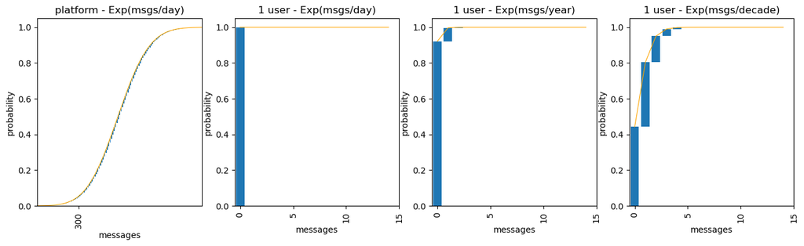

```python
f, ax = plt.subplots(1, 4, figsize=(16, 4))


def render_poisson(dist, ax, xlim: int = 10, labels_each=1):
    """
    This renders the Cumulative Distribution Function and the Probability Mass Function of the provided poission distribution
    """
    end = int(xlim * 1.5)
    x = np.arange(0, end)
    cdf = list(map(dist.cdf, x))
    pmf = list(map(dist.pmf, x))
    previous = [sum(pmf[:i]) for i in x]
    sns.lineplot(x=x, y=cdf, ax=ax, color="orange", linewidth=0.8)
    ax.bar(x, pmf, bottom=previous)
    charts.rotate_x_labels(ax, each=labels_each)
    ax.set_xlabel("messages")
    ax.set_ylabel("probability")
    ax.set_xlim(-0.5, end)
    ax.set_ylim(0, 1.05)


ax[0].title.set_text("platform - Exp(msgs/day)")
render_poisson(p_platform, ax[0], 350)
ax[0].set_xlim(270, 390)

ax[1].title.set_text("1 user - Exp(msgs/day)")
render_poisson(p_day, ax[1])
ax[1].set_ylim(0, 1.05)

ax[2].title.set_text("1 user - Exp(msgs/year)")
render_poisson(p_year, ax[2])
ax[2].set_ylim(0, 1.05)

ax[3].title.set_text("1 user - Exp(msgs/decade)")
render_poisson(p_decade, ax[3])
ax[3].set_ylim(0, 1.05)
__
```

Let's zoom in on the 3rd chart (which is the one that we're actually interested in), and add a horizontal cut for our confidence interval

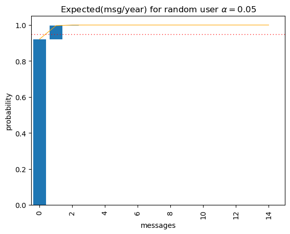

```python
confidence_interval = 1 - alpha_1

ax = plt.gca()
ax.title.set_text(f"Expected(msg/year) for random user $\\alpha = {alpha_1}$")
render_poisson(p_year, ax)
plt.axhline(y=confidence_interval, color="red", dashes=(1, 3), linewidth=1)
ax.set_ylim(0, 1.05)
__
```

```python
cut_bottom, cut_top = p_year.interval(confidence_interval)
cut_bottom, cut_top
```

```
(0.0, 1.0)
```

The values in this range are included in our 95% confidence interval.

```python
md(
    f"""
- This distribution models the average review rate for an average user of our platform, in terms of messages/year.
- We can see that, with a {confidence_interval:.0%} confidence, the average user will write ${cut_top:.0f}$ or fewer messages per year
- We've included a horizontal marker to highlight the confidence interval of {confidence_interval:.0%} ($\\alpha = {alpha_1}$)
- Visually, it seems that the value ${cut_top:.0f}$ is included in our confidence level, but let's calculate it in order to verify it, just to be extra sure:
- This means that if we want to collect the top {alpha_1:.0%} of commenters (in terms of commenter rate), we need to set the cutoff at **{cut_top+1:.0f} or more comment per year**
"""
)
```

- This distribution models the average review rate for an average user of our platform, in terms of messages/year.

- We can see that, with a 95% confidence, the average user will write $1$ or fewer messages per year

- We've included a horizontal marker to highlight the confidence interval of 95% ($\alpha = 0.05$)

- Visually, it seems that the value $1$ is included in our confidence level, but let's calculate it in order to verify it, just to be extra sure:

- This means that if we want to collect the top 5% of commenters (in terms of commenter rate), we need to set the cutoff at **2 or more comment per year**

### Grouping users based on *chattiness*

Now that we have our threshold for chattiness, we want to find all the users that exceed that rate of reviews/year, so we can label them appropriately.

There is one extra thing we want to do:

- We don't want to incorrectly label *bursty* users who maybe commented in a short burst, a few years ago.

We need to find a way to:

- correctly classify users who were "bursty" with their reviews (lots in a short period of time), but who have been quiet since then (on avarage)
- correctly identify users who are very chatty

Since the dataset does not have user account data (sign up date, account deletion date, etc..) we will use the date of the "last review" as the "end of dataset date", and we will use that date are "today", assuming that all the users that ever existed, still exist, and are "alive/active", even if they have not commented recently

[figure not shown]

Let's label all those users

```python
def _():
    max_avg_messages_per_year = cut_top + 1
    one_year = 1 * 365
    q = f"""
    WITH reviews_by_prolific_authors AS (
            SELECT podcast_id, title, content, rating, author_id, created_at
            FROM reviews
        )
    SELECT author_id,
           365 * (COUNT(*) / (JULIANDAY({dataset_end_date}) -
                               JULIANDAY(MIN(created_at)))) / COUNT(DISTINCT author_id)
                   AS avg_reviews_per_year_for_average_author
    FROM reviews_by_prolific_authors
    GROUP BY author_id
    HAVING avg_reviews_per_year_for_average_author >= {max_avg_messages_per_year}
    ORDER BY avg_reviews_per_year_for_average_author DESC;
    """
    df = pd.read_sql_query(q, sqlite)
    display(df)
    return df


chatty_users = _()
```

|  | author_id | avg_reviews_per_year_for_average_author |
| --- | --- | --- |
| 0 | 5A6D2CBF79347E5 | 907.354126 |
| 1 | 0E464C8E02FB8DE | 872.703121 |
| 2 | 623F1591FF836C1 | 849.500310 |
| 3 | 4643BFFE9CD2192 | 820.694322 |
| 4 | B38C556EEDEA2A8 | 673.702200 |
| ... | ... | ... |
| 82222 | B5CBA6CA64635D6 | 2.000180 |
| 82223 | F5FAB9AF7715BFA | 2.000170 |
| 82224 | BFF44D406CFFE27 | 2.000117 |
| 82225 | A7EFC84F3B30E87 | 2.000102 |
| 82226 | 6437995D2E662DF | 2.000097 |

82227 rows × 2 columns

This is it, we have our list of chatty users. The list of non-chatty users are "the rest", by definition.

## Test 2 - Identifying behaviour of chatty users

The next thing we want is to get an understanding of how these users vote/review podcasts.

Specifically we want to find the most well-rated categories that the chatty users reviewed.

We will late do the same with the quiet users, and see if the two lists are different, in a statistically significant way.

Recall that we already created a table for this data, and we indexed it, for performance.

```python
category_rating = pd.read_sql_query("SELECT * FROM category_rating", sqlite)
category_rating
```

|  | podcast_id | category | author_id | rating |
| --- | --- | --- | --- | --- |
| 0 | c61aa81c9b929a66f0c1db6cbe5d8548 | arts | F7E5A318989779D | 5 |
| 1 | c61aa81c9b929a66f0c1db6cbe5d8548 | arts-performing-arts | F7E5A318989779D | 5 |
| 2 | c61aa81c9b929a66f0c1db6cbe5d8548 | music | F7E5A318989779D | 5 |
| 3 | c61aa81c9b929a66f0c1db6cbe5d8548 | arts | F6BF5472689BD12 | 5 |
| 4 | c61aa81c9b929a66f0c1db6cbe5d8548 | arts-performing-arts | F6BF5472689BD12 | 5 |
| ... | ... | ... | ... | ... |
| 4529478 | ec0898451fd6b961c42beceaeec43648 | business-careers | EE7877B6C336602 | 5 |
| 4529479 | ebc36287c28e63f458d55fd2a25e6658 | fiction | F9AF6C4B6E68787 | 5 |
| 4529480 | ebc36287c28e63f458d55fd2a25e6658 | fiction-drama | F9AF6C4B6E68787 | 5 |
| 4529481 | ebc36287c28e63f458d55fd2a25e6658 | music | F9AF6C4B6E68787 | 5 |
| 4529482 | e2a2b0ae82295552b770d84f044d22f0 | kids-family-parenting | 97C061C5152B04E | 5 |

4529483 rows × 4 columns

Since there are two 1:N relations across podcasts:

- podcast-review: 1:N
- podcast-category: 1:N

The joint relation that traverses `category-podcast-review` has a cardinality of M:N.

This results in a difficulty for us: when someone gives a 5-star rating to a podcast that is tagged with 3 categories, it's impossible for us to assign that rating to only one of them. We have to assign that 5-star rating to all the categories of the podcast.

This is one of the core design constraints/choices we had to make for this analysis, and we wanted to be explicit about it.

```python
chatty_users_mask = category_rating["author_id"].isin(chatty_users["author_id"])
chatty_reviews = category_rating[chatty_users_mask].copy()
chatty_reviews
```

|  | podcast_id | category | author_id | rating |
| --- | --- | --- | --- | --- |
| 14 | ad4f2bf69c72b8db75978423c25f379e | arts | D86032C8E57D15A | 5 |
| 15 | ad4f2bf69c72b8db75978423c25f379e | arts-design | D86032C8E57D15A | 5 |
| 16 | ad4f2bf69c72b8db75978423c25f379e | education | D86032C8E57D15A | 5 |
| 17 | ad4f2bf69c72b8db75978423c25f379e | society-culture | D86032C8E57D15A | 5 |
| 22 | ad4f2bf69c72b8db75978423c25f379e | arts | 265ADD6AB150C41 | 3 |
| ... | ... | ... | ... | ... |
| 4529471 | d97df2529d4c69c1528cd73c91fbbc1a | arts-food | A1DFA02E1435F5F | 5 |
| 4529472 | d97df2529d4c69c1528cd73c91fbbc1a | business-marketing | A1DFA02E1435F5F | 5 |
| 4529476 | fe5dc7e58a8bb72a4b2cc4ec43378313 | tv-film | B4C64915C026463 | 5 |
| 4529477 | fe5dc7e58a8bb72a4b2cc4ec43378313 | tv-film-film-reviews | B4C64915C026463 | 5 |
| 4529482 | e2a2b0ae82295552b770d84f044d22f0 | kids-family-parenting | 97C061C5152B04E | 5 |

558355 rows × 4 columns

We want to rate podcasts in a way that includes:

- the number of reviews
- the number of stars in each review

A simple approach is to just sum all the ratings. Unfortunately, this does not reflect the reality, and is exploitable:

- ten 1-star reviews are not the same as two 5-star reviews

So we want to use a points system that acknowledges that 1 is as strong as 5, but in the opposite direction.

So if a podcast ends with 0 points, it could be:

- lots of polarized reviews (5, 1, 5, 1) resulting in +2 -2 +2 -2
- or lots of "meh" reviews with 3 points

```python
chatty_reviews["points"] = chatty_reviews["rating"] - 3
chatty_reviews.sample(10)
```

|  | podcast_id | category | author_id | rating | points |
| --- | --- | --- | --- | --- | --- |
| 3817634 | e549abdedde054751572126b116f4653 | news-news-commentary | F304143A449FEC5 | 5 | 2 |
| 4421312 | b99f93a4924eb3a960d70ae263cd18a1 | sports-football | 6CA2FFB408BC834 | 5 | 2 |
| 4167485 | be30c2d5df4f710fb20e5012c56c6027 | christianity | D42BB501F0D4169 | 1 | -2 |
| 1869524 | aac0cd906f33a44f826a82e609b04de3 | society-culture | 3B15ABDF78AFF3D | 1 | -2 |
| 3699940 | db0d846fe74a4b9fa4d37d7ee1c2374d | kids-family | 84A963B9B50290C | 5 | 2 |
| 1172918 | a5f015cc3e5553c162f49840fc91401f | sports | A0DAAA974A9C7F1 | 5 | 2 |
| 614236 | afe45b3cb50a741ade5798506649d46d | spirituality | 2BCC2756CC290BC | 5 | 2 |
| 4509708 | bd784d3cbca52ca91dc75784eca17039 | comedy | 12ECAF5245F92AB | 3 | 0 |
| 4299573 | bede69aae211565459aceb5f7e8155d3 | news | 3B26AF29C90ED1C | 3 | 0 |
| 4162923 | c9969860076cc3478751601d8f325256 | society-culture | ADBEB8EABC983D3 | 5 | 2 |

```python
normalized_rating_chatty = (
    chatty_reviews.groupby(["podcast_id"]).sum("points") / chatty_reviews.shape[0]
)
normalized_rating_chatty = normalized_rating_chatty.sort_values(
    by="points"
).reset_index()[["podcast_id", "points"]]
normalized_rating_chatty
```

|  | podcast_id | points |
| --- | --- | --- |
| 0 | ed1d26a2f16587ec292421e188f8ee83 | -0.001773 |
| 1 | b834bcf94406863e8484f4ee1f4d7bdf | -0.001003 |
| 2 | bc8b38c671dedeec6f43edf53fc09dce | -0.000910 |
| 3 | bb8e7798573ad16736f48506574ef490 | -0.000838 |
| 4 | ef47233dcfdc0bf67681db6322b57f58 | -0.000623 |
| ... | ... | ... |
| 28433 | c3f080cc393035a81d4ac7c7bff1c6c1 | 0.013235 |
| 28434 | e4f40593687b648068b986ad01bacb7d | 0.014507 |
| 28435 | ddd451a18055f0108edf79f8c3c9bf15 | 0.018929 |
| 28436 | f2377a9b0d9a2e0fb05c3dad55759328 | 0.027975 |
| 28437 | bad6c91efdbee814db985c7a65199604 | 0.046390 |

28438 rows × 2 columns

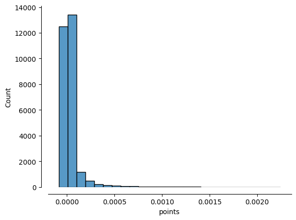

```python
no_outliers = slice(40, -40)

sns.histplot(data=normalized_rating_chatty["points"].iloc[no_outliers], bins=25)
sns.despine(offset=10)
```

```
95% confidence interval cut-off is at 0.00072117654330399
```

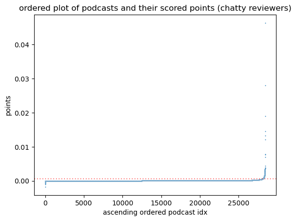

```python
sns.scatterplot(data=normalized_rating_chatty["points"], s=2)

n = stats.norm(
    normalized_rating_chatty["points"].mean(), normalized_rating_chatty["points"].std()
)

ci = 0.95
cut = n.ppf(ci)
print(f"{ci:.0%} confidence interval cut-off is at {cut}")

plt.axhline(y=cut, color="red", dashes=(1, 3), linewidth=1)
plt.title("ordered plot of podcasts and their scored points (chatty reviewers)")
plt.xlabel("ascending ordered podcast idx")
plt.ylabel("points")

__
```

```python
normalized_rating_chatty["liked_by_chatty"] = False
normalized_rating_chatty.loc[
    normalized_rating_chatty["points"] >= cut, "liked_by_chatty"
] = True
normalized_rating_chatty
```

|  | podcast_id | points | liked_by_chatty |
| --- | --- | --- | --- |
| 0 | ed1d26a2f16587ec292421e188f8ee83 | -0.001773 | False |
| 1 | b834bcf94406863e8484f4ee1f4d7bdf | -0.001003 | False |
| 2 | bc8b38c671dedeec6f43edf53fc09dce | -0.000910 | False |
| 3 | bb8e7798573ad16736f48506574ef490 | -0.000838 | False |
| 4 | ef47233dcfdc0bf67681db6322b57f58 | -0.000623 | False |
| ... | ... | ... | ... |
| 28433 | c3f080cc393035a81d4ac7c7bff1c6c1 | 0.013235 | True |
| 28434 | e4f40593687b648068b986ad01bacb7d | 0.014507 | True |
| 28435 | ddd451a18055f0108edf79f8c3c9bf15 | 0.018929 | True |
| 28436 | f2377a9b0d9a2e0fb05c3dad55759328 | 0.027975 | True |
| 28437 | bad6c91efdbee814db985c7a65199604 | 0.046390 | True |

28438 rows × 3 columns

```python
normalized_rating_chatty.groupby("liked_by_chatty").count()
```

| liked_by_chatty | podcast_id | points |
| --- | --- | --- |
| False | 28182 | 28182 |
| True | 256 | 256 |

So, now we have a list of the podcasts that are most liked by our most prolific reviewers.

Now we just need to do the same, but with the votes from our more quiet users.

## Test 3 - Identifying behaviour of quiet users

There will be less explanations in this next section because we're basically doing the same thing again, but for the other subset of users.

The process and calculations are identical

```python
quiet_reviews = category_rating[~chatty_users_mask].copy()
quiet_reviews
```

|  | podcast_id | category | author_id | rating |
| --- | --- | --- | --- | --- |
| 0 | c61aa81c9b929a66f0c1db6cbe5d8548 | arts | F7E5A318989779D | 5 |
| 1 | c61aa81c9b929a66f0c1db6cbe5d8548 | arts-performing-arts | F7E5A318989779D | 5 |
| 2 | c61aa81c9b929a66f0c1db6cbe5d8548 | music | F7E5A318989779D | 5 |
| 3 | c61aa81c9b929a66f0c1db6cbe5d8548 | arts | F6BF5472689BD12 | 5 |
| 4 | c61aa81c9b929a66f0c1db6cbe5d8548 | arts-performing-arts | F6BF5472689BD12 | 5 |
| ... | ... | ... | ... | ... |
| 4529475 | ca0ed0b0822c8f76fe7f41a4027c3907 | leisure-hobbies | C79E747DAA69C6E | 5 |
| 4529478 | ec0898451fd6b961c42beceaeec43648 | business-careers | EE7877B6C336602 | 5 |
| 4529479 | ebc36287c28e63f458d55fd2a25e6658 | fiction | F9AF6C4B6E68787 | 5 |
| 4529480 | ebc36287c28e63f458d55fd2a25e6658 | fiction-drama | F9AF6C4B6E68787 | 5 |
| 4529481 | ebc36287c28e63f458d55fd2a25e6658 | music | F9AF6C4B6E68787 | 5 |

3971128 rows × 4 columns

```python
quiet_reviews["points"] = quiet_reviews["rating"] - 3
quiet_reviews.sample(10)
```

|  | podcast_id | category | author_id | rating | points |
| --- | --- | --- | --- | --- | --- |
| 1557944 | c42ed134d3da288ce81a839a31e01788 | society-culture | 073E6AA6F37E975 | 5 | 2 |
| 1669167 | dd597792a74acca30a727a57dafaa5e4 | society-culture | E494AC09153C0F8 | 5 | 2 |
| 797617 | dd6d9821555aa5ec4fbe4d4125177956 | spirituality | 21C6B1D5E0D3FBF | 5 | 2 |
| 1281686 | e017559e2a6fe1fa9cc384359663cfaf | science-natural-sciences | 043CB3BB81DC033 | 5 | 2 |
| 1266241 | d18048f07e38e2a022c07b4638439321 | sports | 350A0C6391C8C3D | 5 | 2 |
| 4230026 | eec0804d9ff32abaffec2801ebdb97ab | religion-spirituality | F334B03809EFF1D | 5 | 2 |
| 1770307 | f30611ab7a4bc98ce72948e6d6acc48c | society-culture | D737F26A5AF19B3 | 5 | 2 |
| 2264138 | f1a7cabd6127108563a0e38ae044b88a | news-politics | CF25398A83F01C3 | 1 | -2 |
| 3673147 | d90b00729ba79989a9bb306a6eace8e4 | news | B323EC714DE449D | 5 | 2 |
| 1345364 | ac956e444d8701e57793a86c60068eff | business-entrepreneurship | 913528846038CC3 | 5 | 2 |

```python
normalized_rating_quiet = (
    quiet_reviews.groupby(["podcast_id"]).sum("points") / quiet_reviews.shape[0]
)
normalized_rating_quiet = normalized_rating_quiet.sort_values(by="points").reset_index()[
    ["podcast_id", "points"]
]
normalized_rating_quiet
```

|  | podcast_id | points |
| --- | --- | --- |
| 0 | c30927313e578b625c1a264304998a1b | -0.000199 |
| 1 | a5d7ffce17a12e868360ace9964e8eb4 | -0.000176 |
| 2 | e4e555426d61312e7e640935c5b98880 | -0.000156 |
| 3 | d9bf2561a5806773404e4debd048910e | -0.000137 |
| 4 | ae3aa1fed48c0e737cdb3ccfa7efc36e | -0.000107 |
| ... | ... | ... |
| 106898 | f128fb4dc8ebe97bd98a31de66d19b45 | 0.007177 |
| 106899 | c2f3608087c2d9109b0f76a42ce880cb | 0.007369 |
| 106900 | e4f40593687b648068b986ad01bacb7d | 0.007598 |
| 106901 | e6568415fd1b0c32cbefbb4cb6dc78d2 | 0.009572 |
| 106902 | bf5bf76d5b6ffbf9a31bba4480383b7f | 0.010248 |

106903 rows × 2 columns

```
95% confidence interval cut-off is at 0.0001871157189132802
```

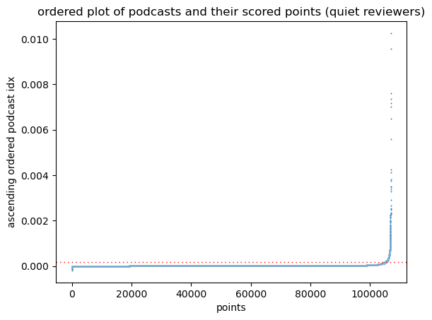

```python
sns.scatterplot(data=normalized_rating_quiet["points"], s=2)

n = stats.norm(
    normalized_rating_quiet["points"].mean(), normalized_rating_quiet["points"].std()
)

ci = 0.95
cut = n.ppf(ci)
print(f"{ci:.0%} confidence interval cut-off is at {cut}")

plt.axhline(y=cut, color="red", dashes=(1, 3), linewidth=1)
plt.title("ordered plot of podcasts and their scored points (quiet reviewers)")
plt.xlabel("points")
plt.ylabel("ascending ordered podcast idx")
__
```

```python
normalized_rating_quiet["liked_by_quiet"] = False
normalized_rating_quiet.loc[
    normalized_rating_quiet["points"] >= cut, "liked_by_quiet"
] = True
normalized_rating_quiet
```

|  | podcast_id | points | liked_by_quiet |
| --- | --- | --- | --- |
| 0 | c30927313e578b625c1a264304998a1b | -0.000199 | False |
| 1 | a5d7ffce17a12e868360ace9964e8eb4 | -0.000176 | False |
| 2 | e4e555426d61312e7e640935c5b98880 | -0.000156 | False |
| 3 | d9bf2561a5806773404e4debd048910e | -0.000137 | False |
| 4 | ae3aa1fed48c0e737cdb3ccfa7efc36e | -0.000107 | False |
| ... | ... | ... | ... |
| 106898 | f128fb4dc8ebe97bd98a31de66d19b45 | 0.007177 | True |
| 106899 | c2f3608087c2d9109b0f76a42ce880cb | 0.007369 | True |
| 106900 | e4f40593687b648068b986ad01bacb7d | 0.007598 | True |
| 106901 | e6568415fd1b0c32cbefbb4cb6dc78d2 | 0.009572 | True |
| 106902 | bf5bf76d5b6ffbf9a31bba4480383b7f | 0.010248 | True |

106903 rows × 3 columns

```python
normalized_rating_quiet.groupby("liked_by_quiet").count()
```

| liked_by_quiet | podcast_id | points |
| --- | --- | --- |
| False | 105298 | 105298 |
| True | 1605 | 1605 |

## Test 4 - Finding differences between *chatty* and *quiet* users

The next thing we need to do is to find similarities between what our chatty users liked, and what our quiet users liked, and see if they behave in a way that we could consider similar (from a statistical point of view)

```python
@run
def _():
    q = """
    SELECT COALESCE(q.podcast_id, c.podcast_id) AS podcast_id,
            COALESCE(liked_by_quiet, false) AS liked_by_quiet,
            COALESCE(liked_by_chatty, false) AS liked_by_chatty
    FROM normalized_rating_quiet q
        FULL OUTER JOIN normalized_rating_chatty c
        ON q.podcast_id = c.podcast_id
    """

    a = "#e9edc9"
    b = "#fcbf49"
    aa = f"background-color: {a}"
    bb = f"background-color: {b}"
    abab = f"background: linear-gradient(to bottom left, {a} 0%, {a} 25%, {b} 25%, {b} 50%, {a} 50%, {a} 75%, {b} 75%, {b} 100%);"

    def highlight_even_rows(row):
        if row.name:
            return [bb, abab]
        else:
            return ["", aa]

    df = (
        duckdb.sql(q)
        .to_df()
        .pivot_table(
            index="liked_by_quiet", columns="liked_by_chatty", aggfunc=np.count_nonzero
        )
    )
    df.columns = df.columns.droplevel(0)
    display(df.style.apply(highlight_even_rows, axis=1))
```

| liked_by_chatty liked_by_quiet | False | True |
| --- | --- | --- |
| False | 108368 | 51 |
| True | 1400 | 205 |

We are specifically interested in comparing the two highlighted areas.

It is not enough to just look at the aggregates, we are interested about the proportions and categories of each of these groups

```python
def _():
    q = """
    SELECT COALESCE(c.podcast_id, q.podcast_id) podcast_id,
           c.points points_chatty,
           COALESCE(c.liked_by_chatty, false) liked_by_chatty,
           q.points points_quiet,
           COALESCE(q.liked_by_quiet, false) liked_by_quiet
    FROM normalized_rating_chatty c
         FULL OUTER JOIN normalized_rating_quiet q
         ON c.podcast_id = q.podcast_id
    WHERE (liked_by_chatty = true
        OR liked_by_quiet = true)
    """
    df = duckdb.sql(q).to_df()
    display(df)
    md("Summary of counts")
    display(pd.DataFrame(df[["liked_by_chatty", "liked_by_quiet"]].value_counts()))
    return df


df_liked_both = _()
```

|  | podcast_id | points_chatty | liked_by_chatty | points_quiet | liked_by_quiet |
| --- | --- | --- | --- | --- | --- |
| 0 | a3db5c2c450d4e6449de7f7e3298fb88 | 0.000036 | False | 0.000461 | True |
| 1 | e2a699a925afa7f51a8df2fd9c560883 | 0.000036 | False | 0.000271 | True |
| 2 | f9b3c233f15df70efd81f2dc5b27435f | 0.000036 | False | 0.000233 | True |
| 3 | adc5cd6b43698deb62b1e4f78509f2c8 | 0.000038 | False | 0.000678 | True |
| 4 | cda16e524f531510a27c8b43d2f4c3f4 | 0.000038 | False | 0.000255 | True |
| ... | ... | ... | ... | ... | ... |
| 1651 | e268e1af435587442a1a78d0344f81b2 | NaN | False | 0.000585 | True |
| 1652 | f4a8f753bd3959e2a631f2eba3c98172 | NaN | False | 0.000619 | True |
| 1653 | cd4baef94ffa1b7afe38d14359f031c2 | NaN | False | 0.000628 | True |
| 1654 | d99d50b773cd0b6fcdde49cfcfd7a1bd | NaN | False | 0.000675 | True |
| 1655 | e5eee1883b25cc3f2fa80fe77976f504 | NaN | False | 0.000800 | True |

1656 rows × 5 columns

Summary of counts

| liked_by_chatty | liked_by_quiet | 0 |
| --- | --- | --- |
| False | True | 1400 |
| True | True | 205 |
|  | False | 51 |

```python
podcast_category = duck.query("SELECT * FROM categories").to_df()

a = """
SELECT c.category,
       SUM(CASE WHEN liked_by_chatty = true THEN 1 ELSE 0 END) AS liked_by_chatty,
       SUM(CASE WHEN liked_by_quiet = true THEN 1 ELSE 0 END) AS liked_by_quiet
FROM df_liked_both liked
    LEFT OUTER JOIN podcast_category c
    ON liked.podcast_id = c.podcast_id
GROUP BY c.category
ORDER BY c.category
"""
liked_proportions = duckdb.sql(a).to_df().set_index("category").T
liked_proportions
```

| category | arts | arts-books | arts-design | arts-fashion-beauty | arts-food | arts-performing-arts | arts-visual-arts | buddhism | business | business-careers | ... | sports-wilderness | sports-wrestling | technology | true-crime | tv-film | tv-film-after-shows | tv-film-film-history | tv-film-film-interviews | tv-film-film-reviews | tv-film-tv-reviews |
| --- | --- | --- | --- | --- | --- | --- | --- | --- | --- | --- | --- | --- | --- | --- | --- | --- | --- | --- | --- | --- | --- |
| liked_by_chatty | 16.0 | 3.0 | 0.0 | 2.0 | 3.0 | 6.0 | 0.0 | 0.0 | 40.0 | 15.0 | ... | 1.0 | 0.0 | 4.0 | 20.0 | 19.0 | 7.0 | 1.0 | 0.0 | 5.0 | 5.0 |
| liked_by_quiet | 160.0 | 26.0 | 15.0 | 22.0 | 22.0 | 32.0 | 25.0 | 1.0 | 238.0 | 75.0 | ... | 27.0 | 12.0 | 37.0 | 61.0 | 128.0 | 21.0 | 8.0 | 8.0 | 19.0 | 18.0 |

2 rows × 101 columns

### Using $\chi^2$ to find differences between user groups

We want to use $\chi^2$ to find if there are *statistically significant* differences between them.

$\chi^2$ allows us to compare both rows and determine if there is any proportionality across them, or if they are behaving fundamentally different.

This is why we need to shape the table with the categories as columns and the "different user groups" as rows.

```python
stat, pvalue, _, _ = stats.contingency.chi2_contingency(liked_proportions)
stat, pvalue
```

```
(173.86335148637207, 6.740837459024919e-06)
```

```python
md(
    f"""We can see that the  $p$-value = {pvalue:.9f} is well below our $\\alpha$ = {alpha_1}"""
)
```

We can see that the $p$-value = 0.000006741 is well below our $\alpha$ = 0.05

This result is very statistically significant, but we would like to have a better understanding of what is hiding behind these numbers

```python
liked_proportions.T.head()
```

| category | liked_by_chatty | liked_by_quiet |
| --- | --- | --- |
| arts | 16.0 | 160.0 |
| arts-books | 3.0 | 26.0 |
| arts-design | 0.0 | 15.0 |
| arts-fashion-beauty | 2.0 | 22.0 |
| arts-food | 3.0 | 22.0 |

```python
liked_proportions.T.sum()
```

```
liked_by_chatty     752.0
liked_by_quiet     4588.0
dtype: float64
```

recall that even though our chatty users comment at a fast rate, the vast majority of reviews are done by the huge number of quiet users.

Let's calculate how each of these categories is liked by each of the 2 groups.

```python
normalized_proportions = liked_proportions.T.apply(lambda x: x / x.sum(), axis=0)

normalized_proportions["ratio_chatty_vs_quiet"] = (
    normalized_proportions["liked_by_chatty"] / normalized_proportions["liked_by_quiet"]
)
normalized_proportions = normalized_proportions.reset_index()
normalized_proportions = normalized_proportions.sort_values(
    by="ratio_chatty_vs_quiet", ascending=False
)


normalized_proportions["primary_category"] = normalized_proportions["category"].apply(
    lambda category: "true_crime"
    if category.startswith("true-crime")
    else category.split("-")[0]
)
normalized_proportions.head()
```

|  | category | liked_by_chatty | liked_by_quiet | ratio_chatty_vs_quiet | primary_category |
| --- | --- | --- | --- | --- | --- |
| 72 | science-nature | 0.003989 | 0.000436 | 9.151596 | science |
| 69 | science-earth-sciences | 0.001330 | 0.000218 | 6.101064 | science |
| 43 | kids-family-stories-for-kids | 0.017287 | 0.003269 | 5.287589 | kids |
| 40 | kids-family-education-for-kids | 0.009309 | 0.002180 | 4.270745 | kids |
| 42 | kids-family-pets-animals | 0.001330 | 0.000436 | 3.050532 | kids |

Let's visualize the spread of boost between "chatty" and "quiet" users (without worrying about the labels, for now)

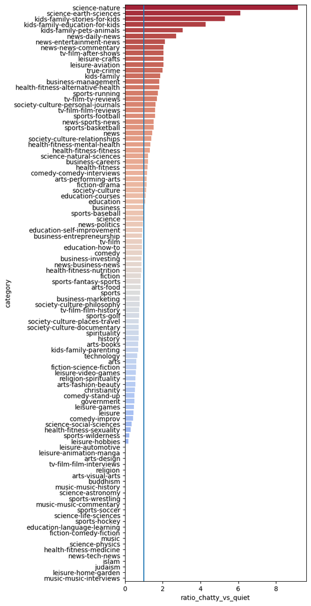

```python
plt.figure(figsize=(5, 16))
ax = sns.barplot(
    data=normalized_proportions,
    orient="h",
    y="category",
    x="ratio_chatty_vs_quiet",
    palette="coolwarm_r",
)

plt.axvline(x=1)
__
```

we can also check the average boost by primary category

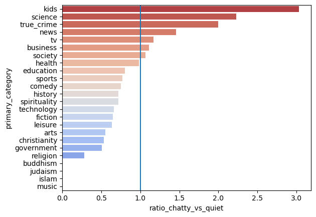

```python
data = (
    normalized_proportions[["primary_category", "ratio_chatty_vs_quiet"]]
    .groupby("primary_category")
    .agg(np.mean)
    .reset_index()
    .sort_values(by="ratio_chatty_vs_quiet", ascending=False)
)

ax = sns.barplot(
    data=data,
    orient="h",
    y="primary_category",
    x="ratio_chatty_vs_quiet",
    palette="coolwarm_r",
)

plt.axvline(x=1)
__
```

It seems that there are some categories (kids, science, true crime, news, tv) that gather lots of attention and engagement from the small subset of very chatty users, while other categories (religions, gov, arts, ...) are way more liked by quiet users than by chatty ones.

With this, we are ready to provide some recommendations and guidelines to boost profits!

```python
sqlite.close()
duck.close()
```

# Overview

This analysis covers the Apple Podcasts ecosystem, from the `thoughtvector/podcastreviews` dataset

It focuses primarily on user reviews to assess user engagement and market segmentation.

Interesting insights:

- The vast majority of users comment less than once per year, showing that the majority of our target market is not actively engaged (for now)
- The vast majority of reviews are 5-star (top score), showing that they are actively following/active within that podcast.

We should use this user's engagement and fervor to make the world a better place (for our stakeholders)

## Executive Summary

- The userbase in Apple Podcasts presents a wide variety of behaviours in terms of engagement
  - Most users engage/review less than 1 podcast per year.
  - There are a small number of very frequent commenters who actively engage and review podcasts.
  - These active community seems particularly interested in kids, science, true crime, and news, and they not only engage more frequently with podcasts, but they also actively enjoy the content of those podcasts, based on their review scores (5-star ratings).
- In order to implement a phased rollout of our monetization plan that ensures early earnings, we must start with these highly engaged users:
  - they represent 5% of the platform
  - they actively use it multiple times per year
  - they enjoy the content they find in our platform
- Should this rollout go well, we can expand it to the rest of users in the future.
- This will also allow us to get early indicators, from a very small sample of the population.
- This should avoid twitter-level mistakes where features were rolled out to everyone causing major uproar and backlash.

## Target Audience for phased rollout

- Target Podcast Categories:
  - kids
  - science
  - true crime
  - news
- Target Users:
  - Users who comment more than 1 per year

Sent from my iPhone